# IE.360 Project | Group 4

#### Kaan Aslan | Serdar Yıldız

## Introduction

Trendyol is the biggest online shopping platform in Turkey. For a company like Trendyol, forecasting the sales is the one of the most crucial parts of the job for numerous reaons. A good predcition of next days sales could provide better storage arrangement, better logistic operations and even better customer recommendations. In this assignment, Trendyol has provided data to forecast 9 products between the dates 11.06.2021 and 26.06.2021. The various 9 products are: - “Oral B Şarjlı Diş Fırçası” - “Sleepy Bebek Islak Mendil” - “La Roche Posay Yüz Temizleyici” - “Fakir Elektrikli Dik Süpürge” - “Xiaomi Bluetooth Kulaklık” - “Trendyolmilla Tayt” - “Trendyolmilla Bikini Üstü 2” - “Trendyolmilla Bikini Üstü 1” - “Altınyıldız Classics Mont”

The descriptive and detailed analysis, and also all model building steps for each product can be reached from HERE.

## Approach

In this assignment 3 time series models are build for each product: ARIMA/SARIMA model, ARIMAX/SARIMAX model and Linear Regresion model. First, for each product the data analysed visually. Then series are decomposed to trend and seasonal components to find if there is any. On these steps, the nature of the data is uncovered. To build ARIMA/SARIMA or ARIMAX/SARIMAX models, the data should be stationary. According to the information from the analysis step, series made stationary and then ARIMA/SARIMA models are build for each product. After the construction of the models, resudial analysis is made to find new regressors to the ARIMA/SARIMA model. The best regressor candidates are selected and added to the models to make them ARIMAX/SARIMAX models.

In the building steps of Linear Regression, first the trend and seasonal components are added to the model. Then, a detailed residual analysis is madde for each product. With the residual analysis, possible regressors are selected from the attributes of the data. The final model is constructed with the regressors that improve the model.

For the validation step, the data is split into test and train series. All the models are constructed on the training period which is between the dates 25.05.2020 and 27.05.2021. The test period is the next 2 weeks after the train period. In the testing step of the each product, models are forecasted the next day and for the other day models are retrained with the new observations. After the testing, results are evaluated according to the weighted mean absolute percentage error to prevent wrong rates which is caused from small prediction intervals for example (0,5). The lowest WMAPE value is choosed to predict the next day. In the forecast steps, again the announced results are added to the models to retrain.

## Results

### Oral B Şarjlı Diş Fırçası

ARIMA/SARIMA model has a WMAPE value of 0.33 while ARIMAX/SARIMAX model has a WMAPE value of 0.32. Also, linear regression model has WMAPE value of 0.13 on the testing period. So, linear regression was used to predict the future sales. Total WMAPE value is 0.129 on the competition period. Predictions are shown below.

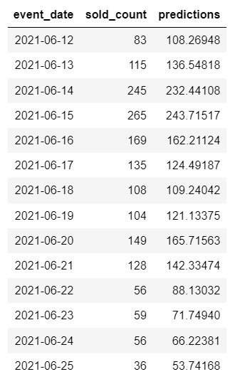

### Sleepy Bebek Islak Mendil

- WMAPE of ARIMA/SARIMA = 0.237.
- WMAPE of ARIMAX/SARIMAX = 0.257.
- WMAPE of LM = 0.141, which is selected as the final model.
- Total WMAPE of competition period = 0.144.

Predictions are below:

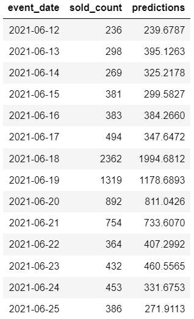

### La Roche Posay Yüz Temizleyici

- WMAPE of ARIMA/SARIMA = 0.205.
- WMAPE of ARIMAX/SARIMAX = 0.255.
- WMAPE of LM = 0.138, which is selected as the final model.
- Total WMAPE of competition period = 0.103.

Predictions are below:

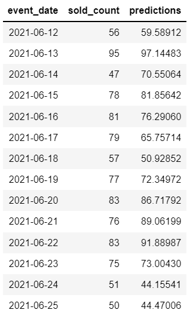

### Fakir Elektrikli Dik Süpürge

Predictions are below:

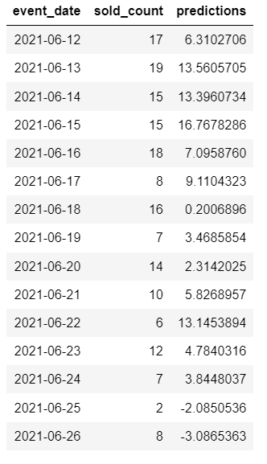

## Xiaomi Bluetooth Kulaklık

- WMAPE of ARIMA/SARIMA = 0.137.
- WMAPE of ARIMAX/SARIMAX = 0.267.
- WMAPE of LM = 0.059, which is selected as the final model.
- Total WMAPE of competition period = 0.096.

Predictions are below:

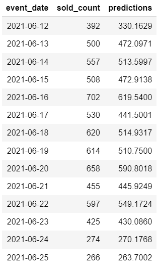

### Trendyolmilla Tayt

- WMAPE of ARIMA/SARIMA = 0.321.
- WMAPE of ARIMAX/SARIMAX = 0.482.
- WMAPE of LM = 0.297, which is selected as the final model.
- Total WMAPE of competition period = 0.185.

Predictions are below:

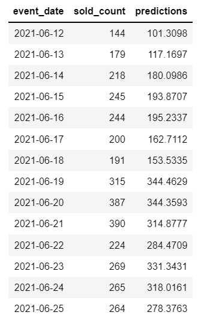

### Trendyolmilla Bikini Üstü 2

- WMAPE of ARIMA/SARIMA = 0.185.
- WMAPE of ARIMAX/SARIMAX = 0.213.
- WMAPE of LM = 0.165, which is selected as the final model.
- Total WMAPE of competition period = 0.107.

Predictions are below:

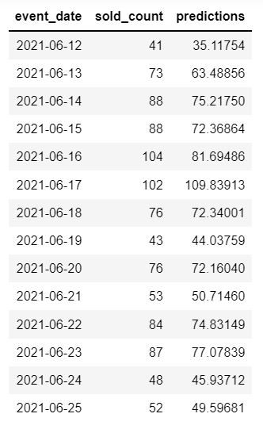

### Trendyolmilla Bikini Üstü 1

- WMAPE of ARIMA/SARIMA = 0.308.
- WMAPE of LM = 0.018, which is selected as the final model.
- Total WMAPE of competition period = 0.058.

Predictions are below:

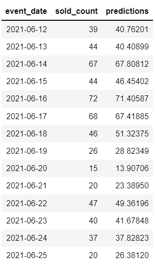

### Altınyıldız Classics Mont

- WMAPE of ARIMA/SARIMA = 0.711.
- WMAPE of ARIMAX/SARIMAX = 0.671.
- WMAPE of LM = 0.442, which is selected as the final model.
- Total WMAPE of competition period = 0.505.

Predictions are below:

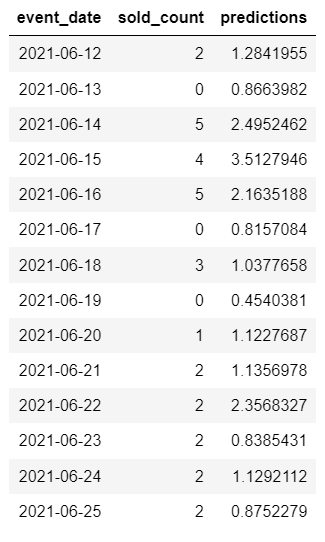

## Conclusion

This project aims to predict the future sales of Trendyol’s 9 different products with linear regression and time series approaches. Firstly, all the products were decomposed at different levels of seasonalities. After, ARIMAX, SARIMAX, and linear regression models were built and tested. On test periods, linear regression models somehow gave us almost the best results. Then, for each product, the best model was used to predict the future sales. After announcing of the real sales, the models were rebuilt and they gave us one-day-after’s predictions.

While building models, some data manipulations were made. The missing values and zero sales made building models hard. Also, the data given has observations for one year, which made analysing the seasonalities hard.

While predicting product of “ALTINYILDIZ MONT”, all the models we built gave terrible predictions because the product was sold only winter season and there were a lot of zero sales on the data. Giving randomly predictions between zero and three may give better results than the models’ outputs.

For better results, GAM models could be used to explain trend and seasonalities. Number of observations should be more than one year in order to understand the seasonal patterns easily. Also, the discount dates could be given. They could help us understand the jumping points on the data.

*PS: Due to the time limitations, lack of computational power, loss of one of our group member (course withdrawal), and some technical problems, our team could not participate in the competition. We did not submit our predictions to the competition page. Lastly, we gave the predictions for 14 days in the report.*